# Practical Machine Learning Course Project

Jon Breece

December 26, 2015

## Data Preparation

I began by cleaning the data and removing variables with significant numbers of NA or NULL values and timestamp variables. The cleaned dataset – *pml-training_CLEAN.csv* – had 52 predictor variables.

I then loaded the *caret* library, and I used createDataPartition function to split the training dataset in order to cross-validate the model before making predictions on the testing dataset supplied by the instructor. I split the data into two and assigned 70 percent of the data to the training set. The training set had 13,737 records.

```r
library(caret)
pml.training <- read.csv("C:/Users/Jon/Desktop/Coursera/Courses/Practical Machine Learning/Project/pml-training_CLEAN.csv")

set.seed(111)
inTrain <- createDataPartition(y=pml.training$classe,p=0.7,list=FALSE)
training<- pml.training[inTrain,]
testing<- pml.training[-inTrain,]
dim(training)
```

```
## [1] 13737    53
```

```r
dim(testing)
```

```
## [1] 5885   53
```

## Building Model

I chose to use random forest algorithm because of its high accuracy. I used the randomForest function from the *randomForest* package – because of the expensiveness of the rf method in the *caret* package.

```r
library(randomForest)
```

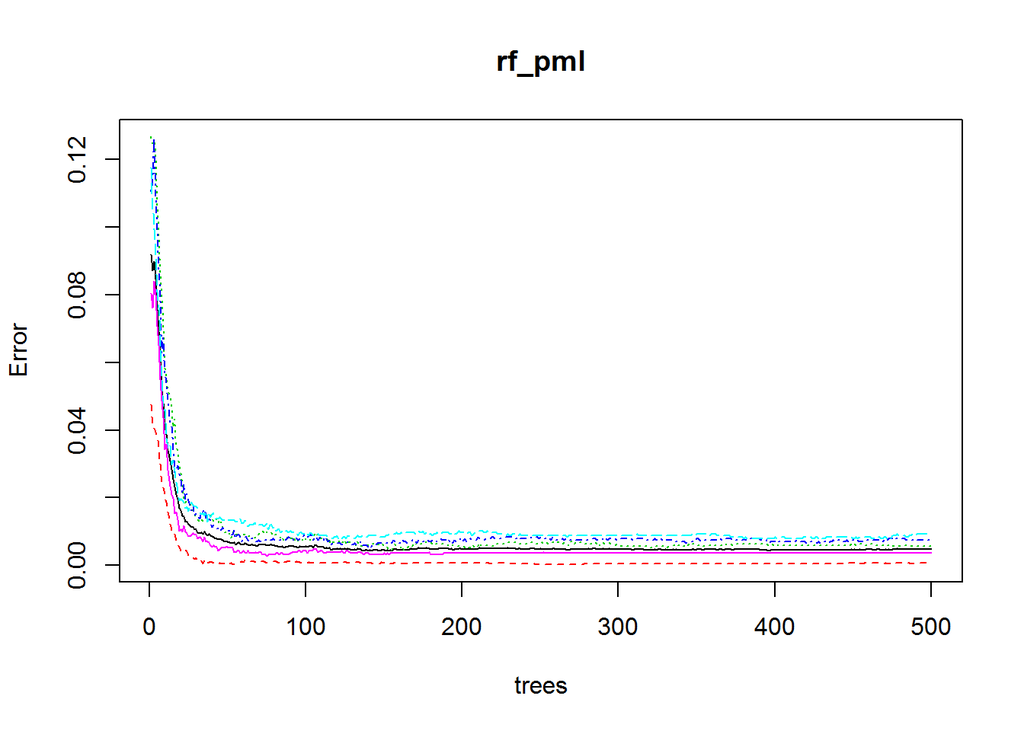

```r
rf_pml <- randomForest(classe~.,data=training,importance=TRUE)

#Plot rf_pml
plot(rf_pml)
```

```r
#Print results of model
rf_pml
```

```
##
## Call:
##  randomForest(formula = classe ~ ., data = training, importance = TRUE)
##                Type of random forest: classification
##                      Number of trees: 500
## No. of variables tried at each split: 7
##
##         OOB estimate of  error rate: 0.48%
## Confusion matrix:
##      A    B    C    D    E  class.error
## A 3903    2    1    0    0 0.0007680492
## B   12 2643    3    0    0 0.0056433409
## C    0   15 2377    4    0 0.0079298831
## D    0    0   20 2232    0 0.0088809947
## E    0    0    1    8 2516 0.0035643564
```

The estimate of error is *0.5 percent*.

After 100 trees the model’s error rate does not improve further. In future work, I could speed processing by decreasing the number of trees built from 500 to 100.

The variables with the highest importance are: yaw_belt roll_belt

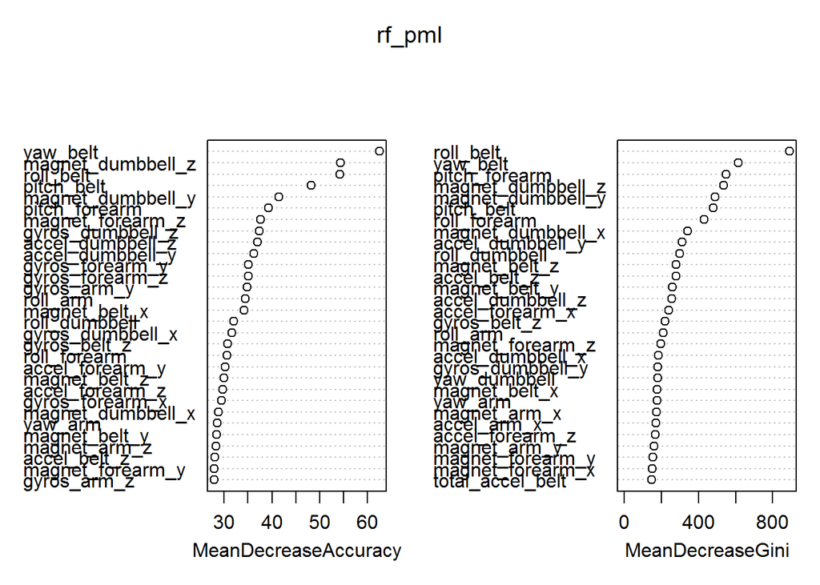

```r
#Explore variable importance
varImpPlot(rf_pml)
```

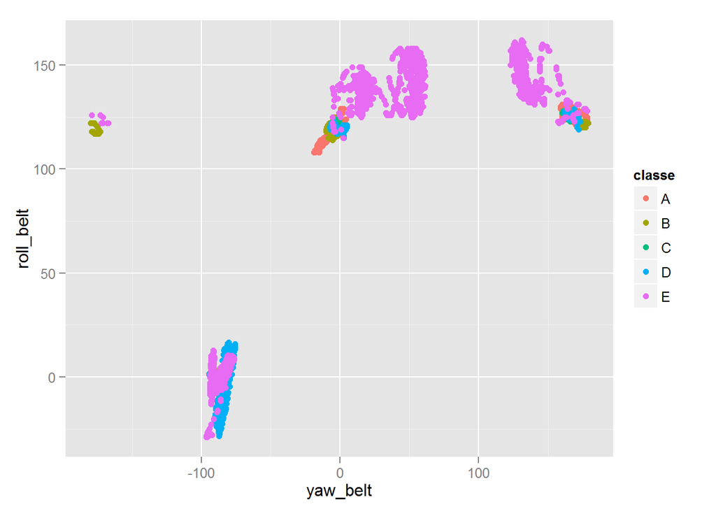

```r
#Class plotted against two most important variables
qplot(yaw_belt,roll_belt,col=classe,data=training)
```

## Cross Validation

I used the remaining records from the instructor-supplied training data to cross-validate the model. When I partitioned the data, I named this set testing. I built two confusion matrices using the two methods showed in the course – with the base table function and with the confusionMatrix function from the caret package.

**Cross Validation with held-out testing data (from the provided training data)**

```r
#Create a confusion matrix with base package table function
pred <- predict(rf_pml,testing)
testing$predRight <- pred==testing$classe
table(pred,testing$classe)
```

```
##
## pred    A    B    C    D    E
##    A 1672    2    0    0    0
##    B    2 1126    3    0    0
##    C    0   11 1023   13    0
##    D    0    0    0  950    3
##    E    0    0    0    1 1079
```

```r
#Using caret package confusionMatrix function:
confusionMatrix(data = pred,testing$classe)
```

```
## Confusion Matrix and Statistics
##
##           Reference
## Prediction    A    B    C    D    E
##          A 1672    2    0    0    0
##          B    2 1126    3    0    0
##          C    0   11 1023   13    0
##          D    0    0    0  950    3
##          E    0    0    0    1 1079
##
## Overall Statistics
##
##                Accuracy : 0.9941
##                  95% CI : (0.9917, 0.9959)
##     No Information Rate : 0.2845
##     P-Value [Acc > NIR] : < 2.2e-16
##
##                   Kappa : 0.9925
##  Mcnemar's Test P-Value : NA
##
## Statistics by Class:
##
##                      Class: A Class: B Class: C Class: D Class: E
## Sensitivity            0.9988   0.9886   0.9971   0.9855   0.9972
## Specificity            0.9995   0.9989   0.9951   0.9994   0.9998
## Pos Pred Value         0.9988   0.9956   0.9771   0.9969   0.9991
## Neg Pred Value         0.9995   0.9973   0.9994   0.9972   0.9994
## Prevalence             0.2845   0.1935   0.1743   0.1638   0.1839
## Detection Rate         0.2841   0.1913   0.1738   0.1614   0.1833
## Detection Prevalence   0.2845   0.1922   0.1779   0.1619   0.1835
## Balanced Accuracy      0.9992   0.9938   0.9961   0.9924   0.9985
```

### Expected out of sample error

Because of this high accuracy (i.e., 99.4 percent; 95 percent confidence interval = 99.1 to 99.6 percent), I expected the out of sample error is less than *1 percent*.

## Final Modeling

The rf_pml model had *100 percent* accuracy predicting the class of the instructor-supplied test data.

## Decisions

1. I cleaned the data to decrease processing time since the majority of values in many of the data attributes were NA or NULL.
2. I chose random forest because of its high accuracy in our previous work in this course. I wanted to benefit from the ensemble nature of the model, a characteristic that lowers the risk of overfitting.
3. I used the randomForest function from the *randomForest* package because of the long processing time when I used rf method in the *caret* package in my preliminary exploration of the data.